# The Tidyverse: dplyr, ggplot2, and friends

This lesson covers packages primarily by Hadley Wickham for tidying data and then working with it in tidy form, collectively known as the “tidyverse”.

The packages we are using in this lesson are all from CRAN, so we can install them with `install.packages`. If you did this while setting up for this workshop, you won’t need to do it again now.

```r
# install.packages("tidyverse")
```

```r
library(tidyverse) # Load all "tidyverse" libraries.
# OR
# library(readr)   # Read tabular data.
# library(tidyr)   # Data frame tidying functions.
# library(dplyr)   # General data frame manipulation.
# library(ggplot2) # Flexible plotting.
```

These packages usually have useful documentation in the form of “vignettes”. These are readable on the CRAN website, or within R:

```r
vignette()
vignette(package="dplyr")
vignette("dplyr", package="dplyr")
```

Many packages also have more extensive vignettes on their own web page.

We will continue using the FastQC output data frame. If you’re starting fresh for this lesson, load it with:

```r
bigtab <- read_csv("r-progtidy-files/fastqc.csv")
```

# dplyr

`dplyr` gives us a collection of convenient “verbs” for manipulating data frames. The name is a contraction of “Data frame apPLYeR”, as some of these verbs have a similar flavour to `apply`/`lapply`/`tapply`/etc.

Each verb takes a data frame as input and returns a modified version of it. The idea is that complex operations can be performed by stringing together a series of simpler operations in a pipeline.

```
# input         +--------+        +--------+        +--------+      result
#  data    |>   |  verb  |   |>   |  verb  |   |>   |  verb  |  ->   data
#   frame       +--------+        +--------+        +--------+        frame
```

Some of these verbs are covered in our [introductory R workshop](https://monashdatafluency.github.io/r-intro-2/data-frames.html), so some of this may be familiar already.

## Tibbles

Because we used `readr` to read the data, `bigtab` is a “tibble”, which is the Tidyverse’s improved data frame.

```r
bigtab
```

```
## # A tibble: 72 × 3
##    grade test                         file
##    <chr> <chr>                        <chr>
##  1 PASS  Basic Statistics             Day0.fastq
##  2 PASS  Per base sequence quality    Day0.fastq
##  3 PASS  Per tile sequence quality    Day0.fastq
##  4 PASS  Per sequence quality scores  Day0.fastq
##  5 FAIL  Per base sequence content    Day0.fastq
##  6 WARN  Per sequence GC content      Day0.fastq
##  7 PASS  Per base N content           Day0.fastq
##  8 PASS  Sequence Length Distribution Day0.fastq
##  9 PASS  Sequence Duplication Levels  Day0.fastq
## 10 WARN  Overrepresented sequences    Day0.fastq
## # ℹ 62 more rows
```

You can also create tibbles explicitly with the `tibble` function. One convenient feature is that it only shows a few rows of the data frame when you print it. If you do want to see the whole table, you can use `as.data.frame`, or use the `View` function to view it in a tab.

```r
as.data.frame(bigtab)
View(bigtab)
```

The `n` and `width` arguments to `print` can also be used to print more rows or columns respectively.

```r
print(bigtab, n=100, width=1000)
```

## filter( )

Say we want to know all the tests that failed. `filter` provides a convenient way to get rows matching a query.

```r
filter(bigtab, grade == "FAIL")
```

```
## # A tibble: 8 × 3
##   grade test                      file
##   <chr> <chr>                     <chr>
## 1 FAIL  Per base sequence content Day0.fastq
## 2 FAIL  Per base sequence content Day4.fastq
## 3 FAIL  Per base sequence content Day7.fastq
## 4 FAIL  Per sequence GC content   Day7.fastq
## 5 FAIL  Per base sequence content Day10.fastq
## 6 FAIL  Per base sequence content Day15.fastq
## 7 FAIL  Per base sequence content Day20.fastq
## 8 FAIL  Per sequence GC content   Day20.fastq
```

Something is magic here: we do not have `grade` in our environment, only within the data frame. Arguments to `filter` can use any column of the data frame as a variable. `dplyr` uses this idea heavily, arguments to `dplyr` verbs often behave in a special way.

## arrange( )

Rather than filtering, we might instead want to sort the data so the most important rows are at the top. `arrange` sorts a data frame by one or more columns.

```r
arrange(bigtab, grade)
```

```
## # A tibble: 72 × 3
##    grade test                      file
##    <chr> <chr>                     <chr>
##  1 FAIL  Per base sequence content Day0.fastq
##  2 FAIL  Per base sequence content Day4.fastq
##  3 FAIL  Per base sequence content Day7.fastq
##  4 FAIL  Per sequence GC content   Day7.fastq
##  5 FAIL  Per base sequence content Day10.fastq
##  6 FAIL  Per base sequence content Day15.fastq
##  7 FAIL  Per base sequence content Day20.fastq
##  8 FAIL  Per sequence GC content   Day20.fastq
##  9 PASS  Basic Statistics          Day0.fastq
## 10 PASS  Per base sequence quality Day0.fastq
## # ℹ 62 more rows
```

```r
# desc( ) can be used to reverse the sort order
arrange(bigtab, desc(grade))
```

```
## # A tibble: 72 × 3
##    grade test                      file
##    <chr> <chr>                     <chr>
##  1 WARN  Per sequence GC content   Day0.fastq
##  2 WARN  Overrepresented sequences Day0.fastq
##  3 WARN  Per sequence GC content   Day4.fastq
##  4 WARN  Per sequence GC content   Day10.fastq
##  5 WARN  Overrepresented sequences Day10.fastq
##  6 WARN  Per sequence GC content   Day15.fastq
##  7 WARN  Overrepresented sequences Day15.fastq
##  8 WARN  Overrepresented sequences Day20.fastq
##  9 PASS  Basic Statistics          Day0.fastq
## 10 PASS  Per base sequence quality Day0.fastq
## # ℹ 62 more rows
```

## Joins

Say we want to convert PASS/WARN/FAIL into a numeric score, so we can produce some numerical summaries. The scoring scheme will be:

```r
fwp <- c("FAIL","WARN","PASS")
scoring <- tibble(grade=factor(fwp,levels=fwp), score=c(0,0.5,1))

scoring
```

```
## # A tibble: 3 × 2
##   grade score
##   <fct> <dbl>
## 1 FAIL    0
## 2 WARN    0.5
## 3 PASS    1
```

`dplyr` has several join functions, including `left_join`, `right_join`, `inner_join`, `full_join`, and `anti_join`. The difference between these functions is what happens when there is a row in one data frame without a corresponding row in the other data frame. `inner_join` discards such rows. `full_join` always keeps them, filling in missing data with NA. `left_join` always keeps rows from the first data frame. `right_join` always keeps rows from the second data frame. `anti_join` is a bit different, it gives you rows from the first data frame that *aren’t* in the second data frame.

We can use a join to augment a data frame with some extra information. `left_join` is a good default choice for this as it will never delete rows from the data frame that is being augmented.

```r
scoretab <- left_join(bigtab, scoring, by="grade")
scoretab
```

```
## # A tibble: 72 × 4
##    grade test                         file       score
##    <chr> <chr>                        <chr>      <dbl>
##  1 PASS  Basic Statistics             Day0.fastq   1
##  2 PASS  Per base sequence quality    Day0.fastq   1
##  3 PASS  Per tile sequence quality    Day0.fastq   1
##  4 PASS  Per sequence quality scores  Day0.fastq   1
##  5 FAIL  Per base sequence content    Day0.fastq   0
##  6 WARN  Per sequence GC content      Day0.fastq   0.5
##  7 PASS  Per base N content           Day0.fastq   1
##  8 PASS  Sequence Length Distribution Day0.fastq   1
##  9 PASS  Sequence Duplication Levels  Day0.fastq   1
## 10 WARN  Overrepresented sequences    Day0.fastq   0.5
## # ℹ 62 more rows
```

The grade columns act as the *keys* of the two data frames, allowing corresponding rows in the data frames to be joined together.

One important thing that all the join functions do: if multiple rows have the same key in either data frame, all ways of combining the two sets of rows will be included in the result. So, here, rows from the scoring data frame have been copied many times in the output.

Joins are the key tool for *integrating* different types of data, based on some common key such as gene ID.

**See also:** `match` and `merge` in base R.

## summarize( )

`summarize` lets us compute summaries of data.

```r
summarize(scoretab, average_score=mean(score))
```

```
## # A tibble: 1 × 1
##   average_score
##           <dbl>
## 1         0.833
```

In this, `average_score` is used to name the new column. Any summary function could be used in place of `mean`, such as `sum`, `median`, `sd`.

We really want to summarize the data grouped by file, so we can see if there are any particularly bad files. This is achieved using the `.by` argument, which names a column or columns to group by. Each group will then produce a single row in the output:

```r
summarize(scoretab, average_score=mean(score), .by=file)
```

```
## # A tibble: 6 × 2
##   file        average_score
##   <chr>               <dbl>
## 1 Day0.fastq          0.833
## 2 Day4.fastq          0.875
## 3 Day7.fastq          0.833
## 4 Day10.fastq         0.833
## 5 Day15.fastq         0.833
## 6 Day20.fastq         0.792
```

For completeness, we should also mention an older way of doing this with the `group_by` helper function, which associates a grouping with the tibble:

```r
group_by(scoretab, file)
```

```
## # A tibble: 72 × 4
## # Groups:   file [6]
##    grade test                         file       score
##    <chr> <chr>                        <chr>      <dbl>
##  1 PASS  Basic Statistics             Day0.fastq   1
##  2 PASS  Per base sequence quality    Day0.fastq   1
##  3 PASS  Per tile sequence quality    Day0.fastq   1
##  4 PASS  Per sequence quality scores  Day0.fastq   1
##  5 FAIL  Per base sequence content    Day0.fastq   0
##  6 WARN  Per sequence GC content      Day0.fastq   0.5
##  7 PASS  Per base N content           Day0.fastq   1
##  8 PASS  Sequence Length Distribution Day0.fastq   1
##  9 PASS  Sequence Duplication Levels  Day0.fastq   1
## 10 WARN  Overrepresented sequences    Day0.fastq   0.5
## # ℹ 62 more rows
```

```r
summarize(group_by(scoretab, file), average_score=mean(score))
```

```
## # A tibble: 6 × 2
##   file        average_score
##   <chr>               <dbl>
## 1 Day0.fastq          0.833
## 2 Day10.fastq         0.833
## 3 Day15.fastq         0.833
## 4 Day20.fastq         0.792
## 5 Day4.fastq          0.875
## 6 Day7.fastq          0.833
```

The special function `n()` can be used within `dplyr` verbs such as `summarize` to get the number of rows.

```r
summarize(scoretab, count=n(), .by=grade)
```

```
## # A tibble: 3 × 2
##   grade count
##   <chr> <int>
## 1 PASS     56
## 2 FAIL      8
## 3 WARN      8
```

**See also:** shortcut functions for simple uses of summarize `count` and `distinct`.

**See also:** `table` and `tapply` in base R.

**Tip:** Other verbs also have a `.by` argument or can be used with `group_by`, such as mutate. This is more advanced than we will be going into today. Grouping with `group_by` can be removed with `ungroup`.

**Tip:** You can group by multiple columns using `c( )`, for example `.by=c(file, grade)`.

## The pipe |>

Suppose we wanted to sort the files by their average score. We could write:

```r
arrange(summarize(scoretab, average_score=mean(score), .by=file), average_score)
```

Writing code like this quickly gets confusing!

We often want to take the result of one `dplyr` function and feed it into another, and another. R’s pipe operator, `|>`, provides a readable way to do this. The pipe operator takes the value on the left, and passes it as the first argument to the function call on the right. So instead we could write:

```r
scoretab |> summarize(average_score=mean(score), .by=file) |> arrange(average_score)
```

For readability we will often write a pipeline over several lines:

```r
scoretab |>
    summarize(average_score=mean(score), .by=file) |>
    arrange(average_score)
```

```
## # A tibble: 6 × 2
##   file        average_score
##   <chr>               <dbl>
## 1 Day20.fastq         0.792
## 2 Day0.fastq          0.833
## 3 Day7.fastq          0.833
## 4 Day10.fastq         0.833
## 5 Day15.fastq         0.833
## 6 Day4.fastq          0.875
```

In older books and web pages you may see `%>%` used instead of `|>`. This is a predecessor to the now standardized R pipe, defined in the `magrittr` package.

`|>` isn’t limited to `dplyr` functions. It’s an alternative way of writing any R code.

```r
rep(paste("hello", "world"), 5)
```

```
## [1] "hello world" "hello world" "hello world" "hello world" "hello world"
```

```r
"hello" |> paste("world") |> rep(5)
```

```
## [1] "hello world" "hello world" "hello world" "hello world" "hello world"
```

The idea of adding geoms in `ggplot2` is rather like piping in `dplyr`. I suspect the only reason pipes aren’t used in `ggplot2` is that it predates `dplyr` and the invention of the pipe.

### Challenge

Write a pipeline using `|>`s that starts with `bigtab`, joins the `scoring` table, and then calculates the average score for each test.

## mutate( )

A couple more verbs will complete our core vocabulary. `mutate` lets us add or overwrite columns by computing a new value for them.

```r
mutate(scoretab, doublescore = score*2)
```

Equivalently:

```r
scoretab |>
    mutate(doublescore = score*2)
```

```
## # A tibble: 72 × 5
##    grade test                         file       score doublescore
##    <chr> <chr>                        <chr>      <dbl>       <dbl>
##  1 PASS  Basic Statistics             Day0.fastq   1             2
##  2 PASS  Per base sequence quality    Day0.fastq   1             2
##  3 PASS  Per tile sequence quality    Day0.fastq   1             2
##  4 PASS  Per sequence quality scores  Day0.fastq   1             2
##  5 FAIL  Per base sequence content    Day0.fastq   0             0
##  6 WARN  Per sequence GC content      Day0.fastq   0.5           1
##  7 PASS  Per base N content           Day0.fastq   1             2
##  8 PASS  Sequence Length Distribution Day0.fastq   1             2
##  9 PASS  Sequence Duplication Levels  Day0.fastq   1             2
## 10 WARN  Overrepresented sequences    Day0.fastq   0.5           1
## # ℹ 62 more rows
```

Even though this is called “mutate”, it is not literally modifying the input. Rather it is producing a copy of the data frame that has the modification.

The above is equivalent to:

```r
scoretab2 <- scoretab
scoretab2$doublescore <- scoretab2$score * 2
```

## select( )

dplyr’s `select` function is for subsetting, renaming, and reordering *columns*. Old columns can be referred to by name or by number.

```r
select(bigtab, test,grade)
```

```
## # A tibble: 72 × 2
##    test                         grade
##    <chr>                        <chr>
##  1 Basic Statistics             PASS
##  2 Per base sequence quality    PASS
##  3 Per tile sequence quality    PASS
##  4 Per sequence quality scores  PASS
##  5 Per base sequence content    FAIL
##  6 Per sequence GC content      WARN
##  7 Per base N content           PASS
##  8 Sequence Length Distribution PASS
##  9 Sequence Duplication Levels  PASS
## 10 Overrepresented sequences    WARN
## # ℹ 62 more rows
```

```r
select(bigtab, 2,1)
```

```
## # A tibble: 72 × 2
##    test                         grade
##    <chr>                        <chr>
##  1 Basic Statistics             PASS
##  2 Per base sequence quality    PASS
##  3 Per tile sequence quality    PASS
##  4 Per sequence quality scores  PASS
##  5 Per base sequence content    FAIL
##  6 Per sequence GC content      WARN
##  7 Per base N content           PASS
##  8 Sequence Length Distribution PASS
##  9 Sequence Duplication Levels  PASS
## 10 Overrepresented sequences    WARN
## # ℹ 62 more rows
```

```r
select(bigtab, foo=file, bar=test, baz=grade)
```

```
## # A tibble: 72 × 3
##    foo        bar                          baz
##    <chr>      <chr>                        <chr>
##  1 Day0.fastq Basic Statistics             PASS
##  2 Day0.fastq Per base sequence quality    PASS
##  3 Day0.fastq Per tile sequence quality    PASS
##  4 Day0.fastq Per sequence quality scores  PASS
##  5 Day0.fastq Per base sequence content    FAIL
##  6 Day0.fastq Per sequence GC content      WARN
##  7 Day0.fastq Per base N content           PASS
##  8 Day0.fastq Sequence Length Distribution PASS
##  9 Day0.fastq Sequence Duplication Levels  PASS
## 10 Day0.fastq Overrepresented sequences    WARN
## # ℹ 62 more rows
```

`select` has a special syntax for more complicated column selections. Read about it [here](https://dplyr.tidyverse.org/reference/dplyr_tidy_select.html). For example, you can remove a specific column like this:

```r
select(bigtab, !file)
```

```
## # A tibble: 72 × 2
##    grade test
##    <chr> <chr>
##  1 PASS  Basic Statistics
##  2 PASS  Per base sequence quality
##  3 PASS  Per tile sequence quality
##  4 PASS  Per sequence quality scores
##  5 FAIL  Per base sequence content
##  6 WARN  Per sequence GC content
##  7 PASS  Per base N content
##  8 PASS  Sequence Length Distribution
##  9 PASS  Sequence Duplication Levels
## 10 WARN  Overrepresented sequences
## # ℹ 62 more rows
```

With `filter`, `arrange`, `mutate`, `select`, `summarize`, and joins, we have a core vocabulary for manipulating data frames in pipelines.

# tidyr

`tidyr` is the Tidyverse package for getting data frames to tidy. In a tidy data frame:

- each row is a single unit of observation
- each column is a single piece of information

Let’s work through a toy example:

```r
untidy <- read_csv(
    "country,     male-young, male-old, female-young, female-old
     Australia,            1,        2,            3,          4
     New Zealand,          5,        6,            7,          8")
untidy
```

```
## # A tibble: 2 × 5
##   country     `male-young` `male-old` `female-young` `female-old`
##   <chr>              <dbl>      <dbl>          <dbl>        <dbl>
## 1 Australia              1          2              3            4
## 2 New Zealand            5          6              7            8
```

In this example, the first problem is that rows are not distinct units of observation, there are actually four observations per row. This is fixed using `pivot_longer`. (This operation has in the past also been called `gather` or `melt`.)

```r
longer <- pivot_longer(untidy, cols=!country, names_to="group", values_to="cases")
longer
```

```
## # A tibble: 8 × 3
##   country     group        cases
##   <chr>       <chr>        <dbl>
## 1 Australia   male-young       1
## 2 Australia   male-old         2
## 3 Australia   female-young     3
## 4 Australia   female-old       4
## 5 New Zealand male-young       5
## 6 New Zealand male-old         6
## 7 New Zealand female-young     7
## 8 New Zealand female-old       8
```

We give a data frame, a specification of columns to use (`cols=`), a column to put the column names in (`names_to=`) and a column to put the values in (`values_to=`). The column specification [behaves like `select`](https://dplyr.tidyverse.org/reference/dplyr_tidy_select.html). Here we’ve asked to used all columns except `country`. We could equivalently have put `cols=2:5`.

`pivot_wider` is the opposite operation, spreading two columns into many columns, which generally makes data less tidy but is sometimes necessary. A common application is producing a scatter plot, where the x and y axes need to be two different columns even though they measure the same type of thing. Data may also be easier to look at in a table in wide form.

```r
pivot_wider(longer, names_from=group, values_from=cases)
```

```
## # A tibble: 2 × 5
##   country     `male-young` `male-old` `female-young` `female-old`
##   <chr>              <dbl>      <dbl>          <dbl>        <dbl>
## 1 Australia              1          2              3            4
## 2 New Zealand            5          6              7            8
```

```r
pivot_wider(bigtab, names_from=file, values_from=grade)
```

```
## # A tibble: 12 × 7
##    test     Day0.fastq Day4.fastq Day7.fastq Day10.fastq Day15.fastq Day20.fastq
##    <chr>    <chr>      <chr>      <chr>      <chr>       <chr>       <chr>
##  1 Basic S… PASS       PASS       PASS       PASS        PASS        PASS
##  2 Per bas… PASS       PASS       PASS       PASS        PASS        PASS
##  3 Per til… PASS       PASS       PASS       PASS        PASS        PASS
##  4 Per seq… PASS       PASS       PASS       PASS        PASS        PASS
##  5 Per bas… FAIL       FAIL       FAIL       FAIL        FAIL        FAIL
##  6 Per seq… WARN       WARN       FAIL       WARN        WARN        FAIL
##  7 Per bas… PASS       PASS       PASS       PASS        PASS        PASS
##  8 Sequenc… PASS       PASS       PASS       PASS        PASS        PASS
##  9 Sequenc… PASS       PASS       PASS       PASS        PASS        PASS
## 10 Overrep… WARN       PASS       PASS       WARN        WARN        WARN
## 11 Adapter… PASS       PASS       PASS       PASS        PASS        PASS
## 12 Kmer Co… PASS       PASS       PASS       PASS        PASS        PASS
```

In our toy example, we have a further problem that the “group” column contains two pieces of data. This can be fixed with `separate`. By default `separate` splits on any non-alphanumeric characters, but different separator characters can be specified.

```r
separate(longer, col=group, into=c("gender","age"))
```

```
## # A tibble: 8 × 4
##   country     gender age   cases
##   <chr>       <chr>  <chr> <dbl>
## 1 Australia   male   young     1
## 2 Australia   male   old       2
## 3 Australia   female young     3
## 4 Australia   female old       4
## 5 New Zealand male   young     5
## 6 New Zealand male   old       6
## 7 New Zealand female young     7
## 8 New Zealand female old       8
```

All of this would typically be written as a single pipline:

```r
tidied <- untidy |>
    pivot_longer(cols=!country, names_to="group", values_to="cases") |>
    separate(group, into=c("gender","age"))
```

Finally, we mention that `pivot_longer` has features we haven’t explored, and it is actually possible to do this in one step. [See the tidyr vignettes.](https://tidyr.tidyverse.org/articles/pivot.html)

```r
pivot_longer(
    untidy, cols=!country,
    names_to=c("gender","age"), names_sep="-", values_to="cases")
```

```
## # A tibble: 8 × 4
##   country     gender age   cases
##   <chr>       <chr>  <chr> <dbl>
## 1 Australia   male   young     1
## 2 Australia   male   old       2
## 3 Australia   female young     3
## 4 Australia   female old       4
## 5 New Zealand male   young     5
## 6 New Zealand male   old       6
## 7 New Zealand female young     7
## 8 New Zealand female old       8
```

**Advanced:** `tidyr` has a number of other useful data frame manipulations. For completeness, we mention `nest`. This creates a *list column* in a tibble, the list column containing one tibble per row. Yo, Hadley put tibbles in your tibble so you can dplyr while you dplyr. The inverse operation is `unnest`. `unnest` is rather like the `bind_rows` function we saw earlier. `nest` and `unnest` go well with creating or modifying list columns in a `mutate` with `lapply` (or the [`purrr`](https://purrr.tidyverse.org/) package).

```r
# Advanced
nested <- nest(tidied, data=c(gender, age, cases))
nested
nested$data
unnest(nested, data)
```

### Challenge

You receive data on a set of points. The points are in two dimensions (`dim`), and each point has x and y coordinates. Unfortunately it looks like this:

```r
df <- read_csv(
    "dim, E_1, E_2, M_1, M_2, M_3, M_4, M_5
     x,   2,   4,   1,   2,   3,   4,   5
     y,   4,   4,   2,   1,   1,   1,   2")
```

1. Tidy the data by pivoting longer all of the columns except `dim`. What does each row now represent?
2. We want to plot the points as a scatter-plot, using either `plot` or `ggplot`. Pivot the long data wider so that this is possible. Now what do the rows represent?
3. The data seems to be divided into “E” and “M” points. How could we make a column containing “E”s and “M”s?

# Other Tidyverse packages

The Tidyverse contains quite a few packages. Here are a few more packages I find myself using often:

- `stringr` for string manipulation. Sometimes `separate` is not quite flexible enough, so I’ll wrangle and disentangle strings with functions like `str_replace_all` and `str_match`.
- `forcats` for manipulating factors.
- `purrr` for `lapply`-like operations.
- `lubridate` for date and time parsing and manipulation.

I also like the `arrow` package for working with large data in parquet format using `dplyr` functions.

# An RNA-Seq example

Recall the diagram from the [“R for Data Science” book](http://r4ds.had.co.nz/). We will here focus on the “import”, “tidy”, “transform”, and “visualize” steps.

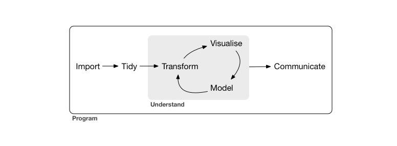

## Importing and tidying

**Hint:** You can select from the top of a pipeline to partway through and press Ctrl-Enter or Command-Enter to see the value part-way through the pipeline.

```r
# Use readr's read_csv function to load the file
counts_untidy <- read_csv("r-progtidy-files/read-counts.csv")
counts <- counts_untidy |>
    pivot_longer(cols=!Feature, names_to="sample", values_to="count") |>
    separate(sample, sep=":", into=c("strain","time"), convert=TRUE, remove=FALSE) |>
    mutate(
        sample = fct_inorder(sample),
        strain = factor(strain, levels=c("WT","SET1","RRP6","SET1-RRP6"))
    ) |>
    filter(time >= 2) |>
    select(sample, strain, time, gene=Feature, count)

summary(counts)
```

```
##      sample           strain         time        gene
##  WT:2   :  45   WT       :405   Min.   : 2   Length:1620
##  WT:3   :  45   SET1     :405   1st Qu.: 4   Class :character
##  WT:4   :  45   RRP6     :405   Median : 6   Mode  :character
##  WT:5   :  45   SET1-RRP6:405   Mean   : 6
##  WT:6   :  45                   3rd Qu.: 8
##  WT:7   :  45                   Max.   :10
##  (Other):1350
##      count
##  Min.   :     0
##  1st Qu.:   172
##  Median :   666
##  Mean   :  3612
##  3rd Qu.:  2548
##  Max.   :143592
##
```

Time point 1 was omitted because it isn’t actually part of the time series, it’s from cells in an unsynchronized state. If we wanted to be even tidier, the remaining time points could be recoded with the actual time within the experiment – they are at 15 minute intervals.

## Transformation and normalization

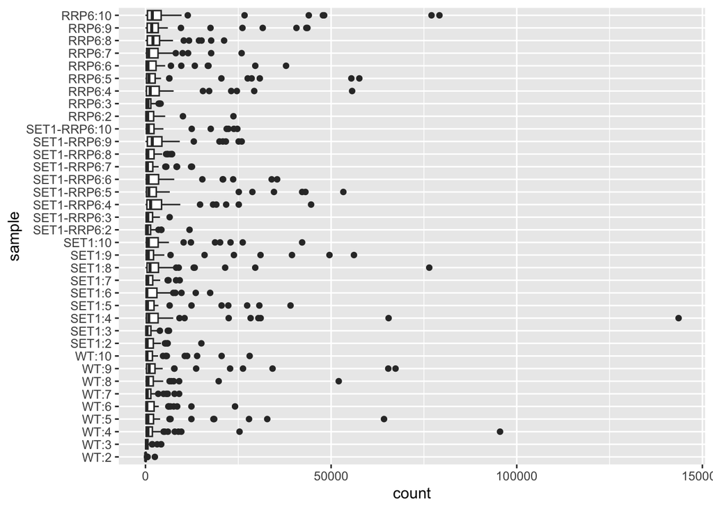

```r
ggplot(counts, aes(x=sample, y=count)) +
    geom_boxplot() +
    coord_flip()
```

We immediately see from a [Tukey](https://www.amazon.com/Exploratory-Data-Analysis-John-Tukey/dp/0201076160/ref=sr_1_1?s=books&ie=UTF8&qid=1469077563&sr=1-1) box plot that the data is far from normal – there are outliers many box-widths to the right of the box.

Perhaps a log transformation is in order.

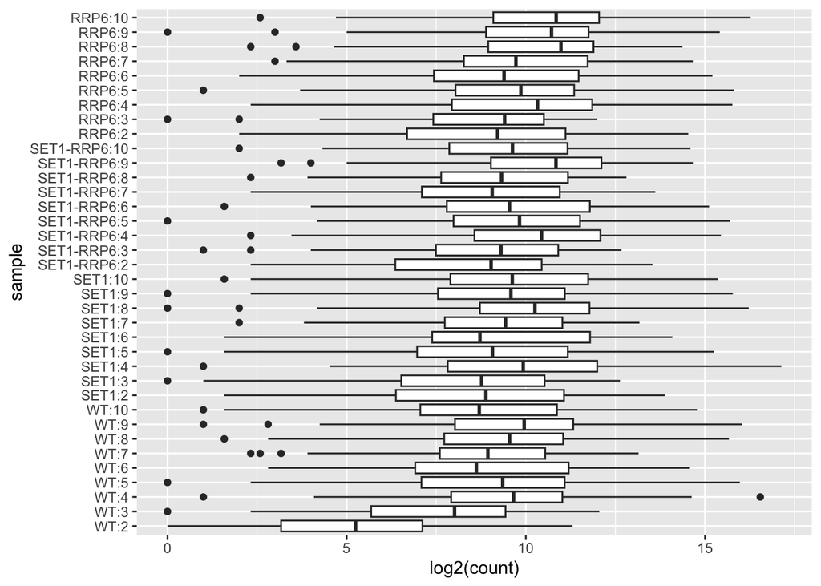

```r
ggplot(counts, aes(x=sample, y=log2(count))) +
    geom_boxplot() +
    coord_flip()
```

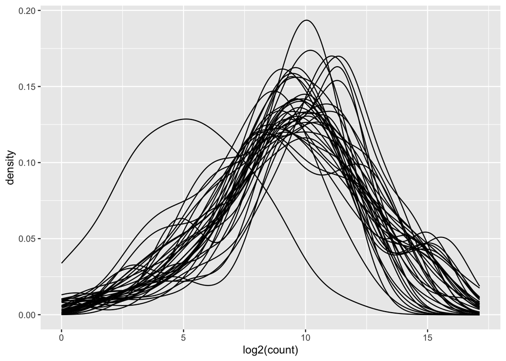

```r
ggplot(counts, aes(x=log2(count), group=sample)) +
    geom_line(stat="density")
```

Log transformation has greatly improved things, although now there are more outliers left of the whiskers, and some zeros we will need to be careful of. We also see one of the samples has less reads than the others.

The gene SRP68 was included as a control housekeeping gene. Its expression level should be the same in all samples. We will divide counts in each sample by a normalization amount to make the normalized count for SRP68 the same in each sample.

```r
counts |> filter(gene == "SRP68") |> pull(count) |> summary()
```

```
##    Min. 1st Qu.  Median    Mean 3rd Qu.    Max.
##      92    1194    1405    1559    1693    3327
```

We see SRP68 has a typical count of around 1500. Let’s normalize so each SRP68 has a count of exactly 1500 in each sample, and then log transform. When log transforming I use log2(norm_count+1). This means a count of zero becomes zero rather than negative infinity, and squishes together small values more than a plain logarithm would. We could squish small values even further by normalizing SRP68 to a lower value. This is a simple form of “variance stabilizing transformation”.

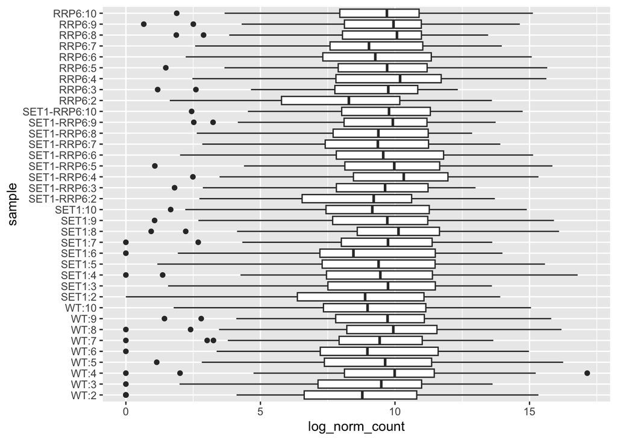

```r
normalizer <- counts |>
    filter(gene == "SRP68") |>
    mutate(norm = count/1500) |>
    select(sample, norm)

counts_norm <- counts |>
    left_join(normalizer, by="sample") |>
    mutate(
        norm_count = count/norm,
        log_norm_count = log2(norm_count+1)
    )

ggplot(counts_norm, aes(x=sample, y=log_norm_count)) +
    geom_boxplot() +
    coord_flip()
```

Note: Here all of the genes are potentially differentially expressed. For a full RNA-Seq data set we would probably assume most genes aren’t differentially expressed, so rather than nominating a normalizing gene we would normalize by total library size. Often units of “Counts Per Million” (CPM) are used. A slight adjustment using the “TMM” method as calculated by `calcNormFactors` in `edgeR` is often applied:

```r
# For a full sized RNA-Seq dataset:
library(edgeR)
mat <- counts_untidy |>
    column_to_rownames("Feature") |>
    as.matrix()
adjusted_lib_sizes <- colSums(mat) * calcNormFactors(mat)
normalizer_by_tmm <- tibble(
    sample=names(adjusted_lib_sizes),
    norm=adjusted_lib_sizes / 1e6)
```

In practice, with a full size RNA-Seq dataset I would use the `edgeR` function `cpm`, which performs the same type of normalization and log transformation as above.

Whatever your data is measuring, two common themes are:

1. Measurement is usually normalized relative to *something* (housekeeping gene, overall library size, microscope image resolution, a ruler in a photograph, calibration run of a machine, …).
2. If the measurement is by nature a positive number, consider log transformation. Two further indications this is appropriate are if you expect the effects of treatmeants to be multiplicative, or if the noise level scales with the magnitude of the measurement.

## Visualization

The data is now suitably transformed and normalized for visualization. `ggplot2` gives us a lot of freedom to juxtapose information from different columns.

Heatmaps using `geom_tile` and the use of facets allow the entire dataset to be viewed at once.

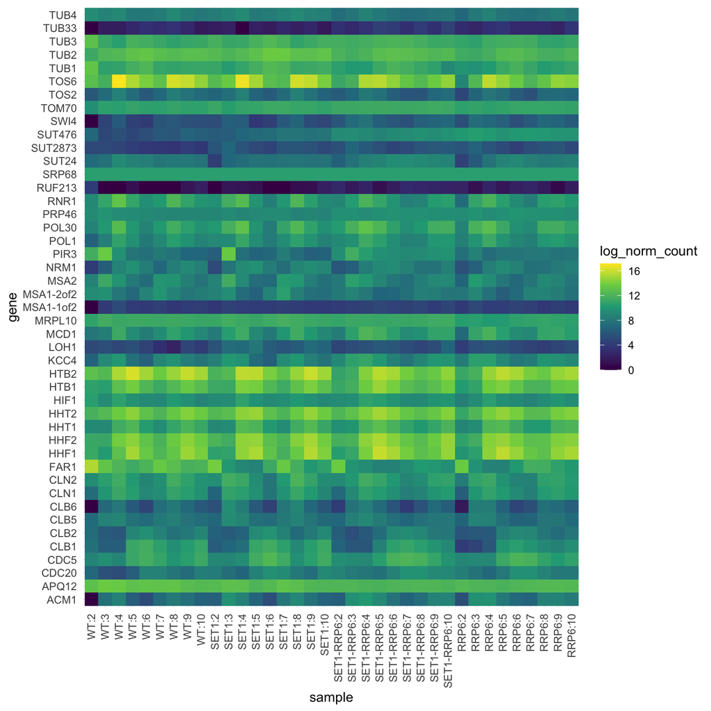

```r
ggplot(counts_norm, aes(x=sample, y=gene, fill=log_norm_count)) +
    geom_tile() +
    scale_fill_viridis_c() +
    theme_minimal() +
    theme(axis.text.x=element_text(           # Vertical text on x axis
              angle=90,vjust=0.5,hjust=1))
```

Facetting the heatmap makes it easier to understand.

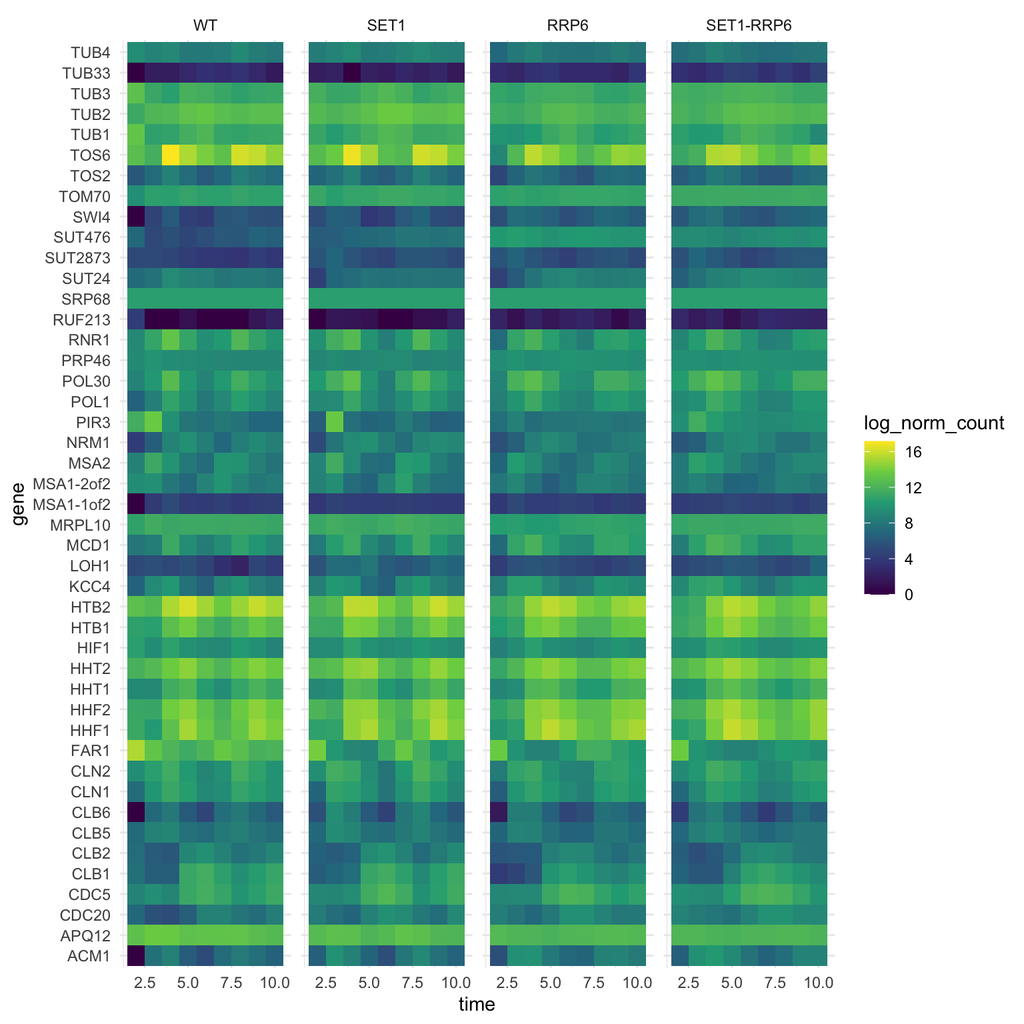

```r
ggplot(counts_norm, aes(x=time, y=gene, fill=log_norm_count)) +
    geom_tile() +
    facet_grid(~ strain) +
    scale_fill_viridis_c() +
    theme_minimal()
```

We are interested in the interaction of strain and time, so we can instead set these as the x and y axes for each gene.

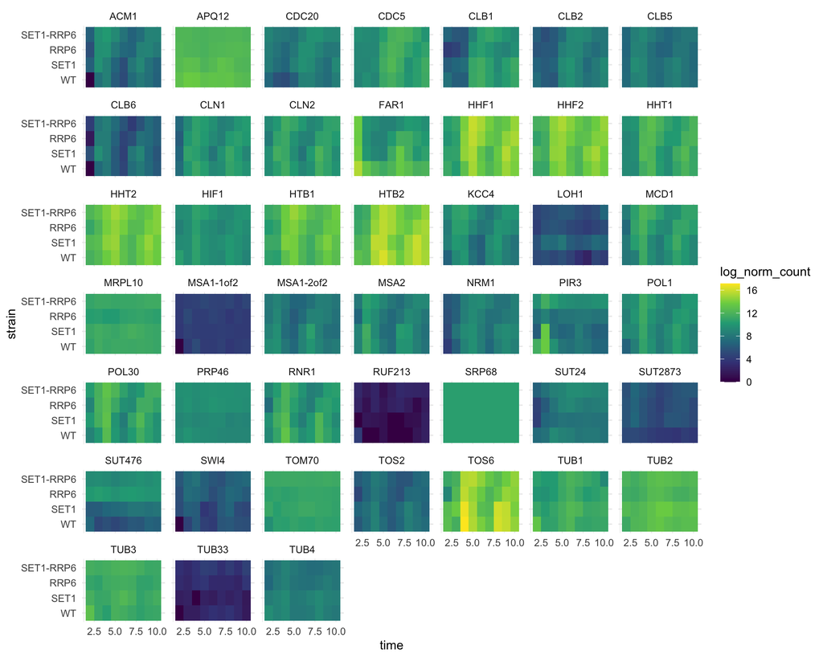

```r
ggplot(counts_norm, aes(x=time, y=strain, fill=log_norm_count)) +
    geom_tile() +
    facet_wrap(~ gene) +
    scale_fill_viridis_c() +
    theme_minimal()
```

A famous paper by Cleveland and McGill (1984) ranks color last in terms of perceptual accuracy. Perhaps a different type of plot will be better?

A more traditional way of examining the interaction between two factors is a line graph called an “interaction plot”. We can also give each gene a separate scale.

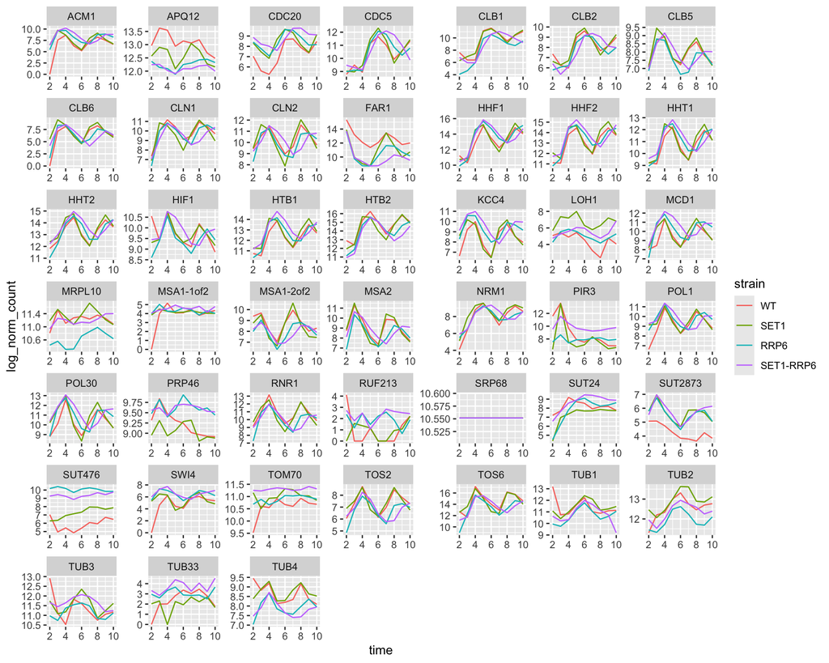

```r
ggplot(counts_norm, aes(x=time, y=log_norm_count, color=strain, group=strain)) +
    geom_line() +
    facet_wrap(~ gene, scale="free")
```

### Exercises

1. Which are the three most variable genes?

Hint: `intToUtf8(utf8ToInt("xvh#jurxsbe|/#vxppdul}h/#vg/#dqg#duudqjh")-3)`

2. Different genes have different average expression levels, but what we are interested in is how they change over time. Further normalize the data by subtracting the average for each gene from `log_norm_count`.

**References**

Cleveland, William S., and Robert McGill. 1984. “Graphical Perception: Theory, Experimentation, and Application to the Development of Graphical Methods.” *Journal of the American Statistical Association* 79 (387): 531–54. https://doi.org/10.1080/01621459.1984.10478080.